# Human activity recognition

Michael Berger

9 April 2018

With the developement of cheap electronics, a trend has been on the rise lately to measure and record all kinds of personal data. One type of such data is accelerometer readings from various fitness trackers during excersises. In this study I am asked to develop a model which will be able to classify performance quality of the excersise based on these readings.

The data is provided by Groupware@LES team of Pontifical Catholic University of Rio de Janeiro. It contains data gathered in a Unilateral Dumbbell Biceps Curl excersise by 5 people done in a correct way and in 4 incorrect ways. The goal of the study is to correctly classify types of mistakes.

## Exploratory analysis

From a brief look on the dataset one can hypothesise that a lot of columns have almost no useful data in them. To check this I make a plot of counts of non-null cells for every column.

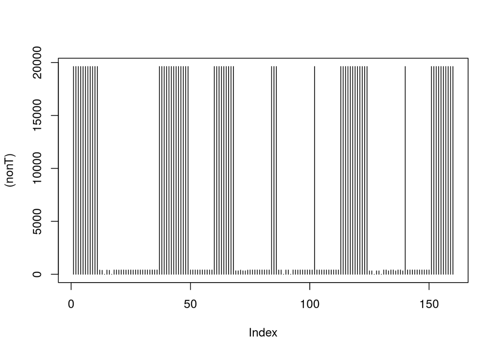

As can be seen on the plot, about a 100 out of 160 variables have less than 3% meaningful data in them. Moreover, there are temporal, entry index and measuring window columns which bear no significant information as well. Deleting these will improve performance and accuracy of the model. In the end I am left with 53 predictor and 1 dependent variables

## Models

I am going to use brute force. Just train a number of models using 7-fold cross validation technique and choose the one with best predictive power. The models I have chosen are: - Gradient boosting model - Linear discriminant analysis - Multiple logistic regression - Naive Bayes - Random Forest Parallel processing will be used to speed things up.

```
##               mdlGbm    mdlLda    mdlMulti      mdlNb       mdlRf
## accuracy   0.9606899 0.7305812   0.7749895  0.7492906   0.9917014
## elapsed  150.9070000 3.4560000 161.9810000 63.7920000 414.0070000
```

```
## [1] 0.9943925
```

```
## Confusion Matrix and Statistics
##
##           Reference
## Prediction    A    B    C    D    E
##          A 1673    2    0    0    0
##          B    0 1133    9    0    0
##          C    0    4 1017   10    3
##          D    0    0    0  952    2
##          E    1    0    0    2 1077
##
## Overall Statistics
##
##                Accuracy : 0.9944
##                  95% CI : (0.9921, 0.9961)
##     No Information Rate : 0.2845
##     P-Value [Acc > NIR] : < 2.2e-16
##
##                   Kappa : 0.9929
##  Mcnemar's Test P-Value : NA
##
## Statistics by Class:
##
##                      Class: A Class: B Class: C Class: D Class: E
## Sensitivity            0.9994   0.9947   0.9912   0.9876   0.9954
## Specificity            0.9995   0.9981   0.9965   0.9996   0.9994
## Pos Pred Value         0.9988   0.9921   0.9836   0.9979   0.9972
## Neg Pred Value         0.9998   0.9987   0.9981   0.9976   0.9990
## Prevalence             0.2845   0.1935   0.1743   0.1638   0.1839
## Detection Rate         0.2843   0.1925   0.1728   0.1618   0.1830
## Detection Prevalence   0.2846   0.1941   0.1757   0.1621   0.1835
## Balanced Accuracy      0.9995   0.9964   0.9939   0.9936   0.9974
```